# Covid Analysis in Utah

Dalton Hall

12/16/2020

Hear are the Libraries used for this project.

Here we read in our data in csv format. We will be looking at case of Covid-19 rate over a 14 day period in utah by county and comparing it against mask compliance data.

The period this data covers is between December 2nd 2020 and December 15th 2020

Since this is wild data, we needed to clean it up a bit into a more presentable format.

```
##    birthsex age_group    compliance   n total percent_compliance
## 1      Male     18-34     Compliant 244   447                55%
## 2      Male     18-34 Not Compliant 203   447                45%
## 3      Male     35-49     Compliant 257   429                60%
## 4      Male     35-49 Not Compliant 172   429                40%
## 5      Male     50-64     Compliant 255   433                59%
## 6      Male     50-64 Not Compliant 178   433                41%
## 7      Male       65+     Compliant 375   544                69%
## 8      Male       65+ Not Compliant 169   544                31%
## 9    Female     18-34     Compliant 233   332                70%
## 10   Female     18-34 Not Compliant  99   332                30%
## 11   Female     35-49     Compliant 341   492                69%
## 12   Female     35-49 Not Compliant 151   492                31%
## 13   Female     50-64     Compliant 286   395                72%
## 14   Female     50-64 Not Compliant 109   395                28%
## 15   Female       65+     Compliant 555   690                80%
## 16   Female       65+ Not Compliant 135   690                20%
```

```
##        county percent_compliant
## 1      Beaver        Suppressed
## 2   Box Elder                59
## 3       Cache                63
## 4      Carbon                54
## 5     Daggett        Suppressed
## 6       Davis                74
## 7    Duchesne                34
## 8       Emery                41
## 9    Garfield        Suppressed
## 10      Grand                65
## 11       Iron                51
## 12       Juab                44
## 13       Kane                45
## 14    Millard                39
## 15     Morgan                54
## 16      Piute        Suppressed
## 17       Rich        Suppressed
## 18  Salt Lake                81
## 19   San Juan                56
## 20    Sanpete                44
## 21     Sevier                36
## 22     Summit                74
## 23     Tooele                67
## 24     Uintah                35
## 25       Utah                66
## 26    Wasatch                74
## 27 Washington                63
## 28      Wayne        Suppressed
## 29      Weber                74
```

```
##          name     jurisdiction x14_day_total_cases x14_day_rate_100k
## 1        KANE   Southwest Utah                 102            1323.1
## 2     MILLARD     Central Utah                 218            1676.1
## 3     SANPETE     Central Utah                 661            2158.5
## 4      CARBON   Southeast Utah                 150             740.0
## 5        UTAH      Utah County                8874            1426.2
## 6       CACHE       Bear River                1691            1330.8
## 7      SUMMIT    Summit County                 380             906.2
## 8  WASHINGTON   Southwest Utah                2561            1491.6
## 9       GRAND   Southeast Utah                  63             645.2
## 10     UINTAH        TriCounty                 262             739.3
## 11     TOOELE    Tooele County                 794            1135.8
## 12     SEVIER     Central Utah                 201             933.2
## 13   GARFIELD   Southwest Utah                  24             472.4
## 14  BOX ELDER       Bear River                 622            1131.9
```

[output cut: 45 more lines]

```
##      age_group birth_sex count percent
## 1    0-1 years    Female   336    46.0
## 2    0-1 years      Male   395    54.0
## 3   1-14 years    Female 10859    50.1
## 4   1-14 years      Male 10817    49.9
## 5  15-24 years    Female 29963    51.3
## 6  15-24 years      Male 28409    48.7
## 7  25-44 years    Female 42091    49.7
## 8  25-44 years      Male 42531    50.3
## 9  45-64 years    Female 26810    50.2
## 10 45-64 years      Male 26642    49.8
## 11 65-84 years    Female  8531    51.5
## 12 65-84 years      Male  8047    48.5
## 13   85+ years    Female  1256    60.8
## 14   85+ years      Male   809    39.2
```

I am still unsatisfied with some column names, so we will be manually renaming them.

```
##       sex   age    compliance individuals_masked_unmasked total
## 1    Male 18-34     Compliant                         244   447
## 2    Male 18-34 Not Compliant                         203   447
## 3    Male 35-49     Compliant                         257   429
## 4    Male 35-49 Not Compliant                         172   429
## 5    Male 50-64     Compliant                         255   433
## 6    Male 50-64 Not Compliant                         178   433
## 7    Male   65+     Compliant                         375   544
## 8    Male   65+ Not Compliant                         169   544
## 9  Female 18-34     Compliant                         233   332
## 10 Female 18-34 Not Compliant                          99   332
## 11 Female 35-49     Compliant                         341   492
## 12 Female 35-49 Not Compliant                         151   492
## 13 Female 50-64     Compliant                         286   395
## 14 Female 50-64 Not Compliant                         109   395
```

[output cut: 19 more lines]

```
##        county     jurisdiction cases_in_period rate_per_100k
## 1        KANE   Southwest Utah             102        1323.1
## 2     MILLARD     Central Utah             218        1676.1
## 3     SANPETE     Central Utah             661        2158.5
## 4      CARBON   Southeast Utah             150         740.0
## 5        UTAH      Utah County            8874        1426.2
## 6       CACHE       Bear River            1691        1330.8
## 7      SUMMIT    Summit County             380         906.2
## 8  WASHINGTON   Southwest Utah            2561        1491.6
## 9       GRAND   Southeast Utah              63         645.2
## 10     UINTAH        TriCounty             262         739.3
## 11     TOOELE    Tooele County             794        1135.8
## 12     SEVIER     Central Utah             201         933.2
## 13   GARFIELD   Southwest Utah              24         472.4
## 14  BOX ELDER       Bear River             622        1131.9
```

[output cut: 45 more lines]

```
##            age    sex case_number percent
## 1    0-1 years Female         336    46.0
## 2    0-1 years   Male         395    54.0
## 3   1-14 years Female       10859    50.1
## 4   1-14 years   Male       10817    49.9
## 5  15-24 years Female       29963    51.3
## 6  15-24 years   Male       28409    48.7
## 7  25-44 years Female       42091    49.7
## 8  25-44 years   Male       42531    50.3
## 9  45-64 years Female       26810    50.2
## 10 45-64 years   Male       26642    49.8
## 11 65-84 years Female        8531    51.5
## 12 65-84 years   Male        8047    48.5
## 13   85+ years Female        1256    60.8
## 14   85+ years   Male         809    39.2
```

Here we are fixing the age column be removing the word years off the end of each row.

```
##      age    sex case_number percent
## 1    0-1 Female         336    46.0
## 2    0-1   Male         395    54.0
## 3   1-14 Female       10859    50.1
## 4   1-14   Male       10817    49.9
## 5  15-24 Female       29963    51.3
## 6  15-24   Male       28409    48.7
## 7  25-44 Female       42091    49.7
## 8  25-44   Male       42531    50.3
## 9  45-64 Female       26810    50.2
## 10 45-64   Male       26642    49.8
## 11 65-84 Female        8531    51.5
## 12 65-84   Male        8047    48.5
## 13   85+ Female        1256    60.8
## 14   85+   Male         809    39.2
```

If we look at mask compliance per county data below, we see that some data is being suppressed, assuming this means we do not have access to this data, we will replace these values with NA.

```
##        county percent_compliant
## 1      Beaver        Suppressed
## 2   Box Elder                59
## 3       Cache                63
## 4      Carbon                54
## 5     Daggett        Suppressed
## 6       Davis                74
## 7    Duchesne                34
## 8       Emery                41
## 9    Garfield        Suppressed
## 10      Grand                65
## 11       Iron                51
## 12       Juab                44
## 13       Kane                45
## 14    Millard                39
## 15     Morgan                54
## 16      Piute        Suppressed
## 17       Rich        Suppressed
## 18  Salt Lake                81
## 19   San Juan                56
## 20    Sanpete                44
## 21     Sevier                36
## 22     Summit                74
## 23     Tooele                67
## 24     Uintah                35
## 25       Utah                66
## 26    Wasatch                74
## 27 Washington                63
## 28      Wayne        Suppressed
## 29      Weber                74
```

```
##        county percent_compliant
## 1      Beaver              <NA>
## 2   Box Elder                59
## 3       Cache                63
## 4      Carbon                54
## 5     Daggett              <NA>
## 6       Davis                74
## 7    Duchesne                34
## 8       Emery                41
## 9    Garfield              <NA>
## 10      Grand                65
## 11       Iron                51
## 12       Juab                44
## 13       Kane                45
## 14    Millard                39
## 15     Morgan                54
## 16      Piute              <NA>
## 17       Rich              <NA>
## 18  Salt Lake                81
## 19   San Juan                56
## 20    Sanpete                44
## 21     Sevier                36
## 22     Summit                74
## 23     Tooele                67
## 24     Uintah                35
## 25       Utah                66
## 26    Wasatch                74
## 27 Washington                63
## 28      Wayne              <NA>
## 29      Weber                74
```

We can see that mask percent is a character but we need it to be a numeric now.

```
## [1] "character"
```

```
## [1] "numeric"
```

Our other data frames look fine for now.

Now that our data is cleaned, let us visualize the data.

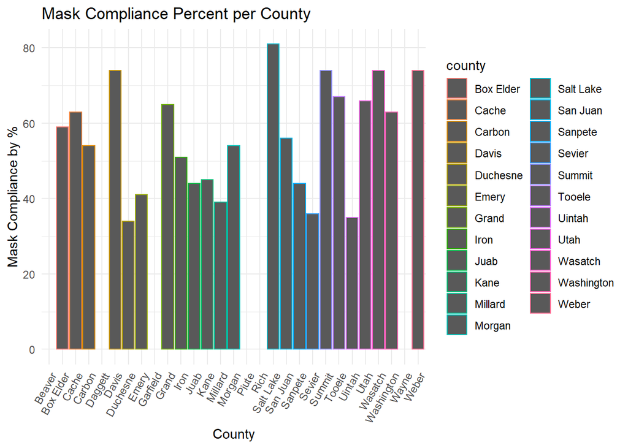

We can see that Salt Lake county has the highest percent of population that wears masks appropriately. While Duchesne and Unitah are competing for the lowest masking.

Next we will visualize how age and sex is correlated to mask observance.

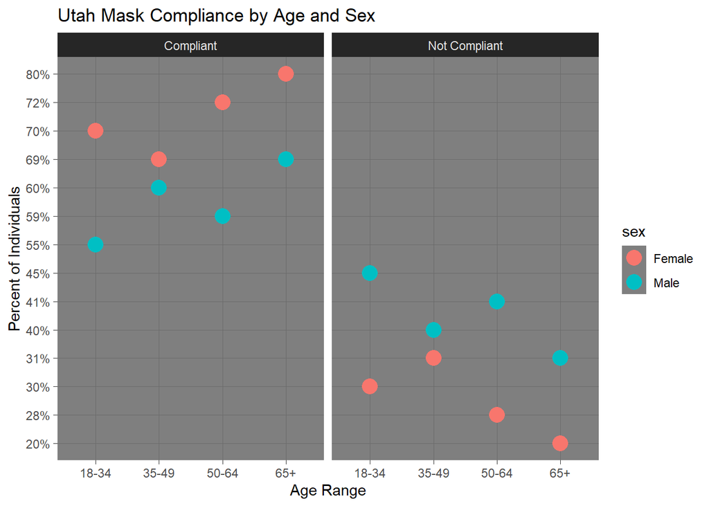

From this we can see that females are overall more likely to wear masks than men at all age ranges. The largest disparity between men and woman wearing masks is the 18-34 age range, followed closely by 50-64 age range. It appears the oldest age 65+ and therefore most susceptible to disease, are the most likely overall to wear masks, while men between 18-34 and woman between 35-49 are least likely to be mask compliant.

Now lets look at Covid case counts per county between Dec 2nd 2020 to Dec 14th 2020

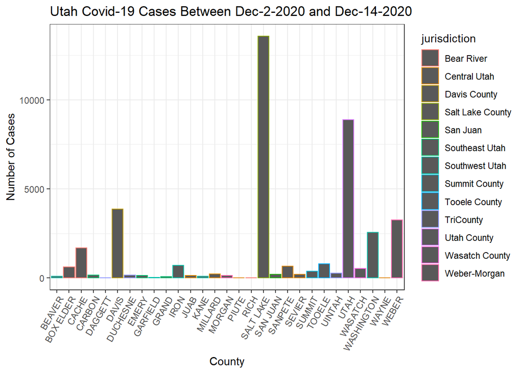

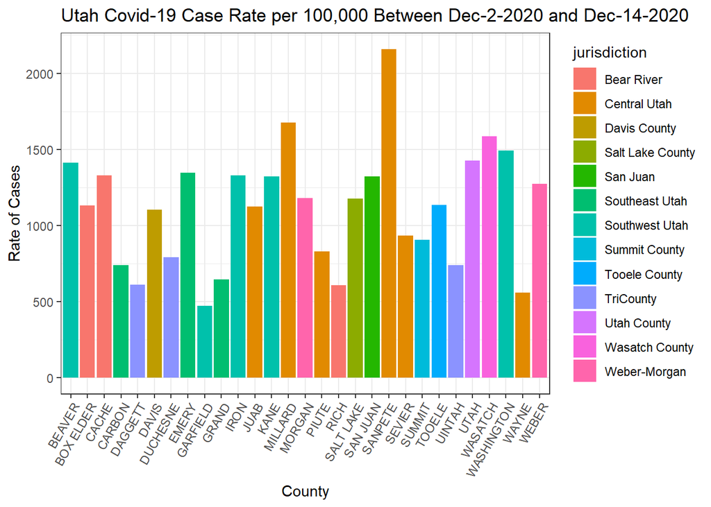

This chart is more fair as we see that Salt Lake only appeared to be doing worse at preventing Covid due to its population density. This time we see Sanpete county taking the lead with Millard county in second place. Interestingly both these counties are under the same Central Utah Jurisdiction.

Now lets take a look at these counties separated out by jurisdiction and see if any more information can be gleaned.

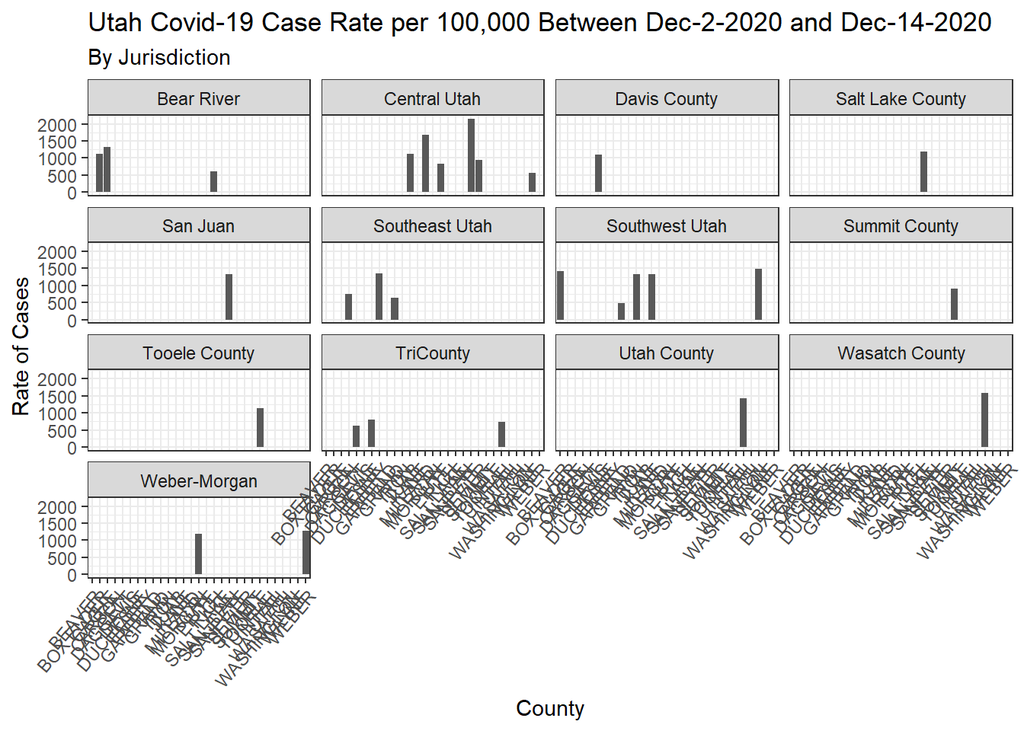

This chart honestly does not give a lot more information besides showing how many counties are in each jurisdiction as well as the lowest rate of cases for jurisdictions with multiple counties.

Lastly, before we compare data side by side, lets look at overall cases in Utah as of Dec-15-2020.

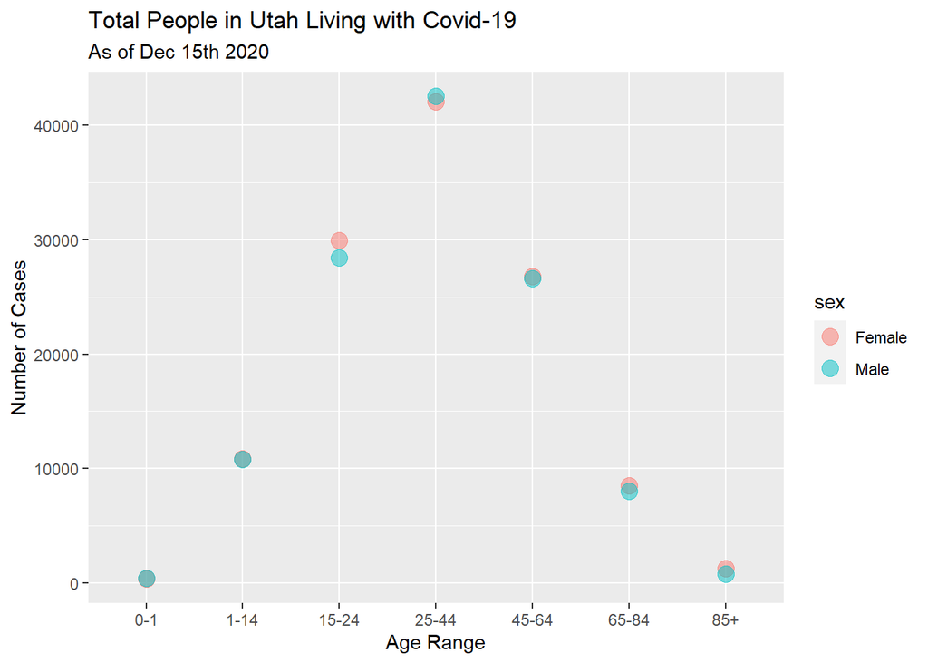

Now that we have visualized our data individually, lets look at some charts side by side to see if we can notice patterns.

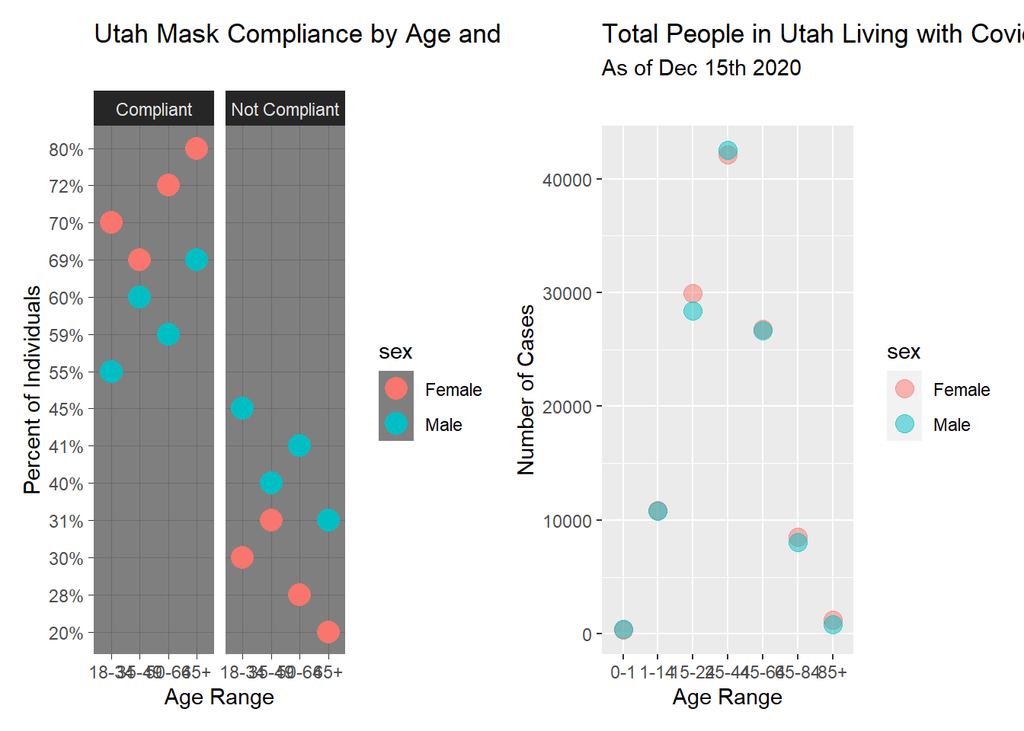

Interestingly, even though males between 18 and 35 are less likely to wear a mask than women of that age range,we see in the total cases that males have notably less cases between age 15-24 currently. Besides that it looks like the even though males across all ages are less likely to wear a mask, that both sexes have about equal case numbers.

Next lets take a look at mask and case data per county side by side.

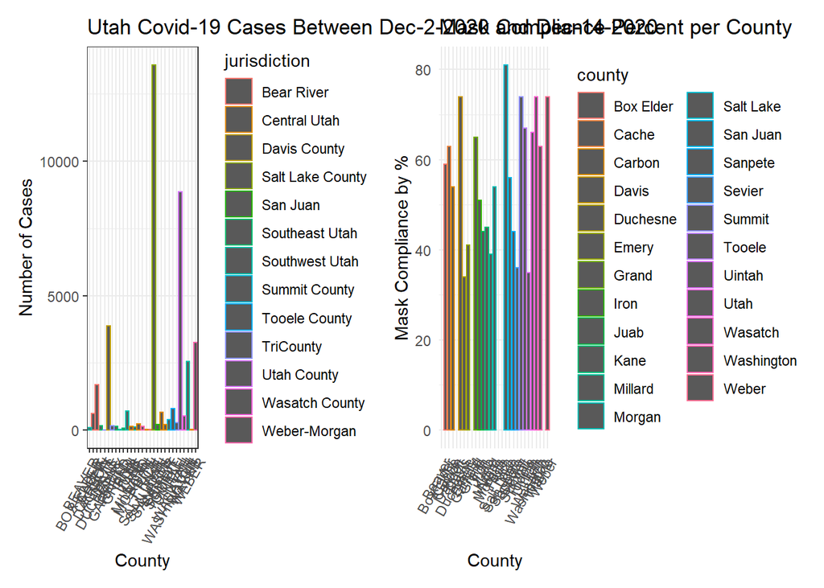

According to this comparison it would appear that even though Salt Lake county is one of the most mask compliant counties, they have significantly more virus spreading than every other county. One could assume that masks do literally nothing if given just these two charts, but next lets look at a more accurate representation of cases next to mask compliance.

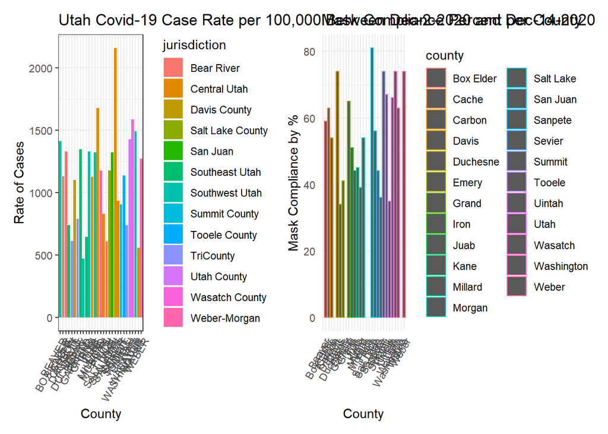

When the cases are turned into rates per 100,000 individuals the story changes. Salt Lake county suddenly becomes average while the Central Utah jurisdiction struggles with high case rate. Comparing this to masks compliance in the two highest rate counties of Sanpete and Millard, we see that these two counties have some of the lowest mask compliance in utah, which is a completely opposite view of the previous comparison.

In addition to this, we see some counties with lowest rate of cases did not have values provided for mask compliant and instead were labeled as “suppressed”, this information would have been very useful in seeing if masks truly do help prevent the spread of Covid-19. Also interestingly, Uintah county has both one of the lowest case rates as well as lowest mask compliance.

Conclusion: Given the data we went over today, it is not possible to derive the significance of mask compliance. A review of a much larger data set with perhaps more variables and comparisons would shine more llight on the subject and perhaps paint a clearer picture.